# Data Analysis for Social Sciences Lab 2

Importing libraries

```python
from __future__ import division
import pandas as pd
import numpy as np
import statsmodels.api as sm
import statsmodels.formula.api as smf
import os
import matplotlib.pyplot as plt
```

```python
os.getcwd()
gss = pd.read_csv("/Users/shreyanskothari/Desktop/Data Analysis for Social Sciences/Labs/Lab1/GSS.2006.csv.xls")
gss.head(10)
```

|  | vpsu | vstrat | adults | ballot | dateintv | famgen | form | formwt | gender1 | hompop | ... | away7 | gender14 | old14 | relate14 | relhh14 | relhhd14 | relsp14 | where12 | where6 | where7 |
| --- | --- | --- | --- | --- | --- | --- | --- | --- | --- | --- | --- | --- | --- | --- | --- | --- | --- | --- | --- | --- | --- |
| 0 | 1 | 1957 | 1 | 3 | 316 | 2 | 1 | 1 | 2 | 3 | ... | NaN | NaN | NaN | NaN | NaN | NaN | NaN | NaN | NaN | NaN |
| 1 | 1 | 1957 | 2 | 2 | 630 | 1 | 2 | 1 | 2 | 2 | ... | NaN | NaN | NaN | NaN | NaN | NaN | NaN | NaN | NaN | NaN |
| 2 | 1 | 1957 | 2 | 2 | 314 | 2 | 1 | 1 | 2 | 2 | ... | NaN | NaN | NaN | NaN | NaN | NaN | NaN | NaN | NaN | NaN |
| 3 | 1 | 1957 | 1 | 1 | 313 | 1 | 2 | 1 | 2 | 1 | ... | NaN | NaN | NaN | NaN | NaN | NaN | NaN | NaN | NaN | NaN |
| 4 | 1 | 1957 | 3 | 1 | 322 | 2 | 2 | 1 | 2 | 3 | ... | NaN | NaN | NaN | NaN | NaN | NaN | NaN | NaN | NaN | NaN |
| 5 | 1 | 1957 | 2 | 2 | 709 | 2 | 2 | 1 | 1 | 4 | ... | NaN | NaN | NaN | NaN | NaN | NaN | NaN | NaN | NaN | NaN |
| 6 | 1 | 1957 | 1 | 3 | 610 | 2 | 2 | 1 | 2 | 2 | ... | NaN | NaN | NaN | NaN | NaN | NaN | NaN | NaN | NaN | NaN |
| 7 | 2 | 1957 | 3 | 4 | 324 | 2 | 1 | 1 | 2 | 3 | ... | NaN | NaN | NaN | NaN | NaN | NaN | NaN | NaN | NaN | NaN |
| 8 | 2 | 1957 | 1 | 3 | 709 | 1 | 2 | 1 | 2 | 1 | ... | NaN | NaN | NaN | NaN | NaN | NaN | NaN | NaN | NaN | NaN |
| 9 | 2 | 1957 | 2 | 1 | 630 | 2 | 1 | 1 | 2 | 4 | ... | NaN | NaN | NaN | NaN | NaN | NaN | NaN | NaN | NaN | NaN |

10 rows × 1261 columns

### 1) Recode 1 *sort of* continuous variable into categories. Tell me what you did and explain the variable(s).

hrs1: If working, full or part time, how many hours did you work last week, at all jobs?

```python
pd.DataFrame(gss.hrs1.describe())
```

|  | hrs1 |
| --- | --- |
| count | 2739.000000 |
| mean | 42.076305 |
| std | 14.231662 |
| min | 1.000000 |
| 25% | 38.000000 |
| 50% | 40.000000 |
| 75% | 50.000000 |
| max | 89.000000 |

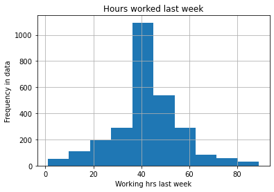

```python
gss.hist('hrs1')
plt.title("Hours worked last week")
plt.xlabel("Working hrs last week")
plt.ylabel("Frequency in data")
```

```python
# Creating a categorical variable for hours worked last week:
conditions = [
            (gss['hrs1']<=20),
            (gss['hrs1']>20) & (gss['hrs1']<=40),
            (gss['hrs1'] >40)]
choices = [1, 2, 3]
gss['workhrs'] = np.select(conditions, choices, default = np.nan)
gss.workhrs.describe()
```

```
count    2739.000000
mean        2.321285
std         0.630161
min         1.000000
25%         2.000000
50%         2.000000
75%         3.000000
max         3.000000
Name: workhrs, dtype: float64
```

```python
gss.workhrs.value_counts()
```

```
2.0    1369
3.0    1125
1.0     245
Name: workhrs, dtype: int64
```

```python
res = pd.crosstab(gss.hrs1, gss.workhrs)
res.astype('float').div(res.sum(axis=0), axis=1)
```

| workhrs hrs1 | 1.0 | 2.0 | 3.0 |
| --- | --- | --- | --- |
| 1.0 | 0.016327 | 0.0 | 0.000000 |
| 2.0 | 0.004082 | 0.0 | 0.000000 |
| 3.0 | 0.008163 | 0.0 | 0.000000 |
| 4.0 | 0.032653 | 0.0 | 0.000000 |
| 5.0 | 0.020408 | 0.0 | 0.000000 |
| ... | ... | ... | ... |
| 84.0 | 0.000000 | 0.0 | 0.000889 |
| 85.0 | 0.000000 | 0.0 | 0.002667 |
| 86.0 | 0.000000 | 0.0 | 0.000889 |
| 88.0 | 0.000000 | 0.0 | 0.000889 |
| 89.0 | 0.000000 | 0.0 | 0.017778 |

80 rows × 3 columns

I chose a continuous variable: hrs1, which depicts number of hours the respondent worked last week. Then I created three conditions for categories: less than 20hrs (coded as 1), between 20 and 40 hrs (coded as 2), and more than 40 hrs (coded as 3). I used the select function from the numpy package to create the recoded variable named 'workhrs'; I provided the condition and the choices to the select function which recoded the hrs1 variable into a categorical variable.

### 2) Recode 1 another variable and attach value labels. Tell me what you did and explain the variable(s).

```python
gss.sei.describe()
```

```
count    4242.000000
mean       49.409595
std        19.599476
min        17.100000
25%        32.799999
50%        42.200001
75%        64.099998
max        97.199997
Name: sei, dtype: float64
```

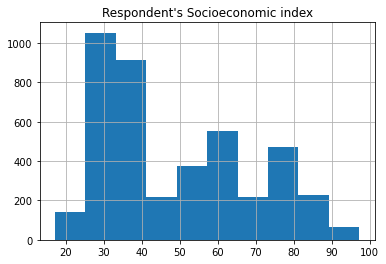

```python
gss.hist('sei')
plt.title("Respondent's Socioeconomic index")
```

```python
bins = [(gss['sei']<=40),
        (gss['sei']>40) & (gss['sei']<=60),
        (gss['sei']>60)
]
labels = ["low","medium","high"]
gss['seindex'] = np.select(bins, labels, default = np.nan)
```

```python
gss.seindex.describe()
```

```
count     4510
unique       4
top        low
freq      2089
Name: seindex, dtype: object
```

```python
pd.crosstab(gss.sei, gss.seindex)
```

| seindex sei | high | low | medium |
| --- | --- | --- | --- |
| 17.100000 | 0 | 13 | 0 |
| 17.600000 | 0 | 3 | 0 |
| 18.500000 | 0 | 5 | 0 |
| 19.500000 | 0 | 2 | 0 |
| 20.100000 | 0 | 5 | 0 |
| ... | ... | ... | ... |
| 92.300003 | 28 | 0 | 0 |
| 92.800003 | 3 | 0 | 0 |
| 93.300003 | 8 | 0 | 0 |
| 96.000000 | 2 | 0 | 0 |
| 97.199997 | 20 | 0 | 0 |

273 rows × 3 columns

I chose a continuous variable sei: the socioeconomic index of the respondent. I created three bins for sei, less than and equal to 40 (low), between 40 and 60 (medium), greater than 60 (high). I used the select function from the numpy package to create the recoded variable named 'seindex'; I provided the bins and the labels to the select function which recoded the sei variable into a categorical variable called seindex.

### 3) 3. Use one (or both) of your recoded variables to do a cross-tabulation. Explain your results.

```python
tabcross = pd.crosstab(gss.workhrs, gss.seindex)
tabcross.columns.tolist()
```

```
['high', 'low', 'medium', 'nan']
```

```python
tabcross = tabcross[['low', 'medium', 'high', 'nan']]
tabcross
```

| seindex workhrs | low | medium | high | nan |
| --- | --- | --- | --- | --- |
| 1.0 | 134 | 27 | 84 | 0 |
| 2.0 | 699 | 215 | 441 | 14 |
| 3.0 | 401 | 199 | 499 | 26 |

```python
tabcross1 = pd.crosstab(gss.workhrs, gss.seindex, normalize = 'columns')*100
tabcross1 = tabcross1[['low', 'medium', 'high', 'nan']]
tabcross1
```

| seindex workhrs | low | medium | high | nan |
| --- | --- | --- | --- | --- |
| 1.0 | 10.858995 | 6.122449 | 8.203125 | 0.0 |
| 2.0 | 56.645057 | 48.752834 | 43.066406 | 35.0 |
| 3.0 | 32.495948 | 45.124717 | 48.730469 | 65.0 |

```python
pd.crosstab(gss.seindex, gss.workhrs, normalize = 'columns')*100
```

| workhrs seindex | 1.0 | 2.0 | 3.0 |
| --- | --- | --- | --- |
| high | 34.285714 | 32.213294 | 44.355556 |
| low | 54.693878 | 51.059167 | 35.644444 |
| medium | 11.020408 | 15.704894 | 17.688889 |
| nan | 0.000000 | 1.022644 | 2.311111 |

In the cross tabulation of working hours and socioeconomic index, we can see that people on the higher end of the socioeconomic index generally tend to work more than 20 hours a week and very few of them (~8%) work less than 20 hours a week. Most of the people in the middle of the socioeconomic index tend to work between 20 and 40 hours a week; only about 6% of them work less than 20 hours a week. For people in the lower end of the socioeconomic index, more than half of them work between 20 and 40 hours a week; only about 32% of them work more than 40 hours. Before reading this cross tabulation, I would have assumed that more people in the lower end of the index worked more than 40 hours a week but that clearly does not seem to be the case. I lso expected to see less people in the higher end of the index working more than 40 hours a week- which is also not the case.

In the cross tab of socioeconomic index and working hours, we see that most of the people who work more than 40 hours a week tend to be on the higher end of the socioeconomic index and most of the people who work less than 20 hours a week tend to be on the lower end of the socioeconomic index. This seems counterintuitive.

### 4) Run a linear regression with 1 independent and 1 dependent variable. Make all of the recodes necessary to make the model as easy to interpret as possible. And explain your results.

```python
#respondent income in dollars - Independent Variable
gss.conrinc.describe()
```

```
count      2669.000000
mean      35211.710753
std       33886.520013
min         441.000000
25%       14334.000000
50%       28668.000000
75%       48516.000000
max      189740.000000
Name: conrinc, dtype: float64
```

```
array([[<AxesSubplot:title={'center':'conrinc'}>]], dtype=object)
```

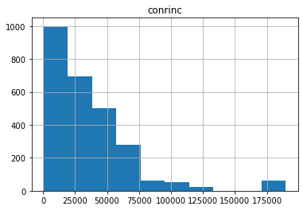

```python
gss.hist('conrinc')
```

```python
# respondent's occupational prestige score - Dependent Variable
gss.prestg80.describe()
```

```
count    4270.000000
mean       44.167447
std        13.999459
min        17.000000
25%        33.000000
50%        43.000000
75%        51.000000
max        86.000000
Name: prestg80, dtype: float64
```

##### Question: How is the income status of the respondent associated with their occupational prestige score?

Recoding conrinc, the income of respondents in dollars, into a categorical variable with three labels: low income (less than 25000), medium income (between 25000 and 65000), and high income (more than 65000). New variable incstat (income status) is a categorical variable with three classes: low income, medium income, and high income.

```python
bins1 = [(gss['conrinc']<=25000),
        (gss['conrinc']>25000) & (gss['conrinc']<=65000),
        (gss['conrinc']>65000)
]
labels1 = ["low income","medium income","high income"]
gss['incstat'] = np.select(bins1, labels1, default = np.nan)
```

```python
gss.incstat.describe
```

```
<bound method NDFrame.describe of 0       medium income
1       medium income
2                 nan
3          low income
4                 nan
            ...
4505      high income
4506              nan
4507       low income
4508              nan
4509              nan
Name: incstat, Length: 4510, dtype: object>
```

```python
pd.crosstab(gss.conrinc, gss.incstat).head(10)
```

| incstat conrinc | high income | low income | medium income |
| --- | --- | --- | --- |
| 441.0 | 0 | 53 | 0 |
| 1764.0 | 0 | 75 | 0 |
| 3087.0 | 0 | 47 | 0 |
| 3969.0 | 0 | 53 | 0 |
| 4852.0 | 0 | 41 | 0 |
| 5734.0 | 0 | 42 | 0 |
| 6616.0 | 0 | 37 | 0 |
| 7939.0 | 0 | 61 | 0 |
| 9924.0 | 0 | 123 | 0 |
| 12129.0 | 0 | 108 | 0 |

```python
# Regression income status on occupational prestige score
lm = smf.ols(formula = 'prestg80~incstat', data = gss).fit()
print (lm.summary())
```

```
                            OLS Regression Results
==============================================================================
Dep. Variable:               prestg80   R-squared:                       0.162
Model:                            OLS   Adj. R-squared:                  0.161
Method:                 Least Squares   F-statistic:                     255.7
Date:                Thu, 21 Oct 2021   Prob (F-statistic):          2.78e-102
Time:                        00:33:43   Log-Likelihood:                -10589.
No. Observations:                2655   AIC:                         2.118e+04
Df Residuals:                    2652   BIC:                         2.120e+04
Df Model:                           2
Covariance Type:            nonrobust
============================================================================================
                               coef    std err          t      P>|t|      [0.025      0.975]
--------------------------------------------------------------------------------------------
Intercept                   55.4186      0.753     73.577      0.000      53.942      56.896
incstat[T.low income]      -16.1344      0.837    -19.286      0.000     -17.775     -14.494
incstat[T.medium income]    -6.9674      0.853     -8.169      0.000      -8.640      -5.295
==============================================================================
Omnibus:                       99.940   Durbin-Watson:                   1.920
Prob(Omnibus):                  0.000   Jarque-Bera (JB):               93.612
Skew:                           0.410   Prob(JB):                     4.70e-21
Kurtosis:                       2.583   Cond. No.                         6.29
==============================================================================

Notes:
[1] Standard Errors assume that the covariance matrix of the errors is correctly specified.
```

### 5) Plot two variables, either as a scatter plot or boxplot. Explain your results.

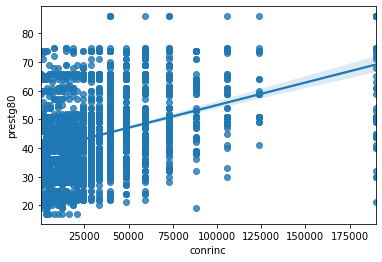

```python
import seaborn as sns
# Plotting income in dollars against occupational prestige score
sns.regplot(x = 'conrinc', y = 'prestg80', data = gss)
```

In this graph, we visualize the relationship between the respondents' income in constant dollars and their occupational prestige score. There seems to be a positive relationship between the two: high income level is associated with a high prestige score.

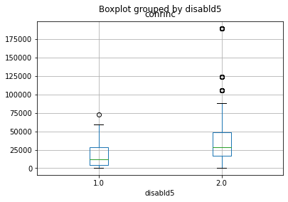

```python
gss.boxplot(column = 'conrinc', by = 'disabld5')
```

The boxplot looks at respondent's income in dollars grouped by disabld5: a categorical variable for whether the respondent has emotional or mental disabilities, where 1 signifies yes and 2 signifies no. In this data, respondents who don't have emotional or mental disabilities tend to have higher income in dollars on an average. They also tend to have a bigger range of income than individuals who do have mental or emotional disabilities. For the group with mental or emotional disabilites, there seems to be an outlier who earns around $75000 which is above the third quartile for the other group's income range.

### 6) Tell me two theories/ideas you might want to test in this course. Do you have a dataset for these ideas/theories already? Do you have it in R-readable format already? What is your main independent variable? What is your main dependent variable?

##### Theory 1: I hope to explore the relationship, if one exists, between income inequality and carbon emissions. My hypothesis is that there exists a positive relationship between income inequality and consumption-based carbon emissions.

For the target / dependent variable: I hope to look at consumption-side carbon emission. I found a dataset for residential carbon dioxide emissions from fossil fuel combustion, measured in million metric tons CO2 (MMTCO2). The source is the United States Environmental Protection Agency (EPA).

For the feature / independent variable: I hope to use a combination of the gini index and the theil index. The Mark Frank’s U.S. State-Level Income Inequality Database contains data on the theil index. I will have to do a little more exploration to find a good dataset on the gini.

The datasets are not in python-readable format yet and require a little bit of cleaning and preprocessing.

##### Theory 2: I hope to explore and analzye current trends in the stock market (specifically tech related stocks) and compare them to the dot com bubble to see if there are any similarities

For the target / dependent variable: current stock prices

For the feature / independent variable: stock prices from during, before, and right after the dot com bubble

This idea is not as formed as the other idea and hence I don't have any potenital data sets.